# Data Mining - Market Basket Analysis

Srushti Padade

April 13, 2020

# Problem Statement

Analyse the Market to know the Groceries Purchase analysis.

Below are the libraries used to perform the market basket analysis on Groceries dataset.

```r
library(dplyr)
library(arules)
```

```r
library(arulesViz)
library(plyr)
options(warn = 1)
```

Loading the dataset and checking the summary of the data.

```r
df_groceries <- read.csv("groceries_v2.csv")
head(df_groceries)
```

```
##       citrus.fruit semi.finished.bread      margarine              ready.soups
## 1   tropical fruit              yogurt         coffee
## 2       whole milk
## 3        pip fruit              yogurt  cream cheese              meat spreads
## 4 other vegetables          whole milk condensed milk long life bakery product
## 5       whole milk              butter         yogurt                     rice
## 6 abrasive cleaner
```

```r
summary(df_groceries)
```

```
##            citrus.fruit         semi.finished.bread            margarine
##  whole milk      :  872                   :3484                     :6114
##  sausage         :  825   whole milk      : 743     whole milk      : 557
##  other vegetables:  583   other vegetables: 620     other vegetables: 440
##  frankfurter     :  580   rolls/buns      : 554     rolls/buns      : 397
##  rolls/buns      :  551   soda            : 488     soda            : 375
##  soda            :  550   root vegetables : 408     yogurt          : 347
##  (Other)         :11332   (Other)         :8996     (Other)         :7063
##            ready.soups
##                  :8216
##  whole milk      : 341
##  rolls/buns      : 307
##  soda            : 302
##  other vegetables: 259
##  yogurt          : 245
##  (Other)         :5623
```

Since the data is transactional type we need to extract the transactions from the dataset of the basket type.

```r
transaction_data = read.transactions(file = "groceries_v2.csv", format = "basket", sep = ",")
```

The data is converted into the set of items in each transaction.

```r
Trans <- as(transaction_data, "transactions")
inspect(Trans[1:5])
```

```
##     items
## [1] {citrus fruit,
##      margarine,
##      ready soups,
##      semi-finished bread}
## [2] {coffee,
##      tropical fruit,
##      yogurt}
## [3] {whole milk}
## [4] {cream cheese,
##      meat spreads,
##      pip fruit,
##      yogurt}
## [5] {condensed milk,
##      long life bakery product,
##      other vegetables,
##      whole milk}
```

Here we can inspect the transactions with the set of similar items purchased.

```r
Trans_ID <- as(transaction_data, "tidLists")
inspect(Trans_ID[1:5])
```

```
##   items
## 1 abrasive cleaner
## 2 artif. sweetener
## 3 baby cosmetics
## 4 baby food
## 5 bags
##   transactionIDs
## 1 {6,34,295,309,638,742,855,868,1148,1229,1341,3027,3149,3975,4032,5611,5810,5967,6170,6321,6405,6682,6741,6754,6869,6905,6928,7360,7543,8174,8281,8931,9078,9767,9791}
## 2 {34,693,853,903,982,1000,1083,1977,2131,2338,2585,3573,3657,4173,4191,4563,4588,5034,5561,5892,6987,7098,7194,7611,8146,8204,8505,8645,9212,9342,9478,9692}
## 3 {482,1214,1491,3382,4841,6632}
## 4 {1092}
## 5 {1746,2823,5141,9619}
```

Apriori is an algorithm for frequent item set mining and association rule learning over relational databases. It proceeds by identifying the frequent individual items in the database and extending them to larger and larger item sets as long as those item sets appear sufficiently often in the database. The frequent item sets determined by Apriori can be used to determine association rules which highlight general trends in the database: this has applications in domains such as market basket analysis.

Here we are having Support = 0.01 and Confidence = 0.5.

```r
Association_rules <- apriori(transaction_data, parameter = list(sup = 0.01, conf = 0.5, target="rules"))
```

```
## Apriori
##
## Parameter specification:
##  confidence minval smax arem  aval originalSupport maxtime support minlen
##         0.5    0.1    1 none FALSE            TRUE       5    0.01      1
##  maxlen target   ext
##      10  rules FALSE
##
## Algorithmic control:
##  filter tree heap memopt load sort verbose
##     0.1 TRUE TRUE  FALSE TRUE    2    TRUE
##
## Absolute minimum support count: 98
##
## set item appearances ...[0 item(s)] done [0.00s].
## set transactions ...[169 item(s), 9834 transaction(s)] done [0.00s].
## sorting and recoding items ... [88 item(s)] done [0.00s].
## creating transaction tree ... done [0.00s].
## checking subsets of size 1 2 3 4 done [0.00s].
## writing ... [15 rule(s)] done [0.00s].
## creating S4 object  ... done [0.00s].
```

```r
summary(Association_rules)
```

```
## set of 15 rules
##
## rule length distribution (lhs + rhs):sizes
##  3
## 15
##
##    Min. 1st Qu.  Median    Mean 3rd Qu.    Max.
##       3       3       3       3       3       3
##
## summary of quality measures:
##     support          confidence          lift           count
##  Min.   :0.01007   Min.   :0.5000   Min.   :1.984   Min.   : 99.0
##  1st Qu.:0.01174   1st Qu.:0.5151   1st Qu.:2.036   1st Qu.:115.5
##  Median :0.01230   Median :0.5245   Median :2.203   Median :121.0
##  Mean   :0.01316   Mean   :0.5411   Mean   :2.300   Mean   :129.4
##  3rd Qu.:0.01403   3rd Qu.:0.5718   3rd Qu.:2.432   3rd Qu.:138.0
##  Max.   :0.02227   Max.   :0.5862   Max.   :3.031   Max.   :219.0
##
## mining info:
##              data ntransactions support confidence
##  transaction_data          9834    0.01        0.5
```

Since the algorithm have do not have sorted association rules, thus below we have sorted the rules based on confidence.

```r
Association_rules_Sorted <- sort(Association_rules, by='confidence', decreasing = TRUE)
summary(Association_rules_Sorted)
```

```
## set of 15 rules
##
## rule length distribution (lhs + rhs):sizes
##  3
## 15
##
##    Min. 1st Qu.  Median    Mean 3rd Qu.    Max.
##       3       3       3       3       3       3
##
## summary of quality measures:
##     support          confidence          lift           count
##  Min.   :0.01007   Min.   :0.5000   Min.   :1.984   Min.   : 99.0
##  1st Qu.:0.01174   1st Qu.:0.5151   1st Qu.:2.036   1st Qu.:115.5
##  Median :0.01230   Median :0.5245   Median :2.203   Median :121.0
##  Mean   :0.01316   Mean   :0.5411   Mean   :2.300   Mean   :129.4
##  3rd Qu.:0.01403   3rd Qu.:0.5718   3rd Qu.:2.432   3rd Qu.:138.0
##  Max.   :0.02227   Max.   :0.5862   Max.   :3.031   Max.   :219.0
##
## mining info:
##              data ntransactions support confidence
##  transaction_data          9834    0.01        0.5
```

The Association rules with there supportand cofidence are as below.

```r
inspect(Association_rules_Sorted)
```

```
##      lhs                                      rhs                support
## [1]  {citrus fruit,root vegetables}        => {other vegetables} 0.01037218
## [2]  {root vegetables,tropical fruit}      => {other vegetables} 0.01230425
## [3]  {curd,yogurt}                         => {whole milk}       0.01006711
## [4]  {butter,other vegetables}             => {whole milk}       0.01149075
## [5]  {root vegetables,tropical fruit}      => {whole milk}       0.01199919
## [6]  {root vegetables,yogurt}              => {whole milk}       0.01454139
## [7]  {domestic eggs,other vegetables}      => {whole milk}       0.01230425
## [8]  {whipped/sour cream,yogurt}           => {whole milk}       0.01088062
## [9]  {rolls/buns,root vegetables}          => {whole milk}       0.01271100
## [10] {other vegetables,pip fruit}          => {whole milk}       0.01352451
## [11] {tropical fruit,yogurt}               => {whole milk}       0.01515152
## [12] {other vegetables,yogurt}             => {whole milk}       0.02226968
## [13] {other vegetables,whipped/sour cream} => {whole milk}       0.01464308
## [14] {rolls/buns,root vegetables}          => {other vegetables} 0.01220256
```

[output cut: 17 more lines]

The Market groceries analysis is seen in the below plot.

[output not shown]

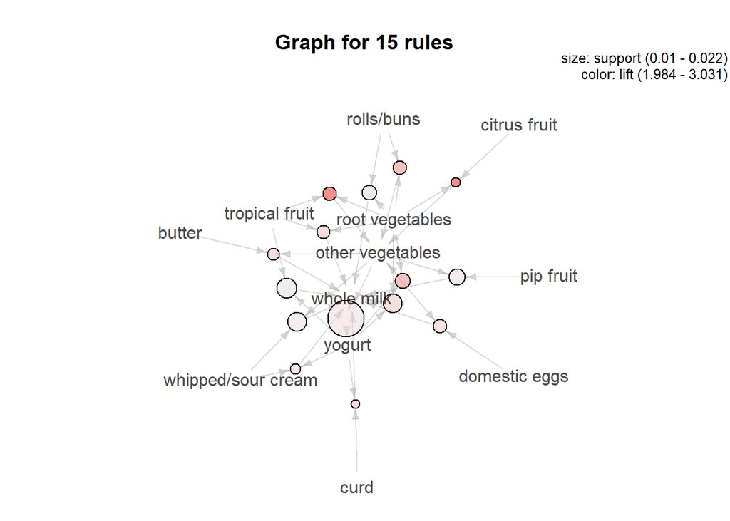

```r
plot(Association_rules_Sorted, method="graph", control=list(type="items"))
```